# Practical Machine Learning Project - AS

A. Swarup

June 12, 2018

## Overview

In this project we’d build a model to analyze the quality of the activities measured by means of fitness tracker devices like Fitbit, Jawbone Up, Nike FuelBand, etc. By using these devices, persons can get quantitative measurement of the activities that they perform, namely, how much are they doing, but not how well are they doing. For this analysis, we’d use data collected from accelerometers on the belt, forearm, arm, and dumbbell of 6 persons. These participants were asked to perform barbell lifts correctly and incorrectly in 5 different ways. More information is available from the website here: http://groupware.les.inf.puc-rio.br/har (see the section on the Weight Lifting Exercise Dataset). Using data from a training dataset, we’d select the predictor variables to be used in our model for the response variable ‘classe’. We’d describe how we built our model, using cross validation, expected out of sample error, etc., and the reasons for choosing the particular prediction model over the others. We’d then use this prediction model to predict 20 different test cases in a given test dataset.

## Load the data

The training data for this project are available here:

https://d396qusza40orc.cloudfront.net/predmachlearn/pml-training.csv

The test data are available here:

https://d396qusza40orc.cloudfront.net/predmachlearn/pml-testing.csv

Original source of the data for this project is:

http://groupware.les.inf.puc-rio.br/har

R code to download from web and read into R is included as below.

```r
rm(list = ls())
library(knitr)
library(ggplot2)
if (!file.exists("pml-training.csv")) {
  download.file("http://d396qusza40orc.cloudfront.net/predmachlearn/pml-training.csv", destfile = "pml-training.csv")
}
if (!file.exists("pml-testing.csv")) {
  download.file("http://d396qusza40orc.cloudfront.net/predmachlearn/pml-testing.csv", destfile = "pml-testing.csv")
}

in_train <- read.csv('./pml-training.csv', header=T, sep = ",", na.strings = c("", "NA", "#DIV/0!"))
testing <- read.csv('./pml-testing.csv', header=T, sep = ",", na.strings = c("", "NA", "#DIV/0!"))
```

## View the data

An examination of the two datasets by the following commands revealed that both sets have 160 columns. The training dataset has 19622 observations and the testing set has 20. It was also noted that both datasets have same column names, except the column 160, which is named ‘classe’ in the training dataset and ‘problem-id’ in the testing. Relevant code for data examination is given as below.

```r
dim(in_train)
```

```
## [1] 19622   160
```

```r
dim(testing)
```

```
## [1]  20 160
```

```r
setdiff(names(in_train),names(testing))
```

```
## [1] "classe"
```

```r
setdiff(names(testing),names(in_train))
```

```
## [1] "problem_id"
```

```r
table(in_train$classe)
```

```
##
##    A    B    C    D    E
## 5580 3797 3422 3216 3607
```

```r
range(testing$problem_id)
```

```
## [1]  1 20
```

Combining results of the last two lines of this code with documentation from section on the Weight Lifting Exercise Dataset, we note that:

- The ‘classe’ column in the training set contains a range of classification identifiers A through E which determine different exercise approaches with A being ‘correct’ and B - E being different types of mistakes.
- The ‘problem_id’ column in the test set contains a set of numeric identifies from 1 through 20.

## Clean up the data

We’d remove all columns that contains NA’s and remove features that are not in the test dataset. The features containing NA are the variance, mean and standard deviation (SD) within each window for each feature. Since the testing dataset has no time-dependence, these values are of no use to us, and we can disregard those. Also, we’d remove the first seven features since they contain time-series data, and are non-numeric.

```r
features <- names(testing[,colSums(is.na(testing)) == 0])[8:59]

in_train <- in_train[,c(features,"classe")]
testing <- testing[,c(features,"problem_id")]

dim(in_train)
```

```
## [1] 19622    53
```

```r
dim(testing)
```

```
## [1] 20 53
```

Just to remind ourselves, we are going to fit a model with the following column names:

```
##  [1] "accel_arm_x"          "accel_arm_y"          "accel_arm_z"
##  [4] "accel_belt_x"         "accel_belt_y"         "accel_belt_z"
##  [7] "accel_dumbbell_x"     "accel_dumbbell_y"     "accel_dumbbell_z"
## [10] "accel_forearm_x"      "accel_forearm_y"      "accel_forearm_z"
## [13] "gyros_arm_x"          "gyros_arm_y"          "gyros_arm_z"
## [16] "gyros_belt_x"         "gyros_belt_y"         "gyros_belt_z"
## [19] "gyros_dumbbell_x"     "gyros_dumbbell_y"     "gyros_dumbbell_z"
## [22] "gyros_forearm_x"      "gyros_forearm_y"      "gyros_forearm_z"
## [25] "magnet_arm_x"         "magnet_arm_y"         "magnet_arm_z"
## [28] "magnet_belt_x"        "magnet_belt_y"        "magnet_belt_z"
## [31] "magnet_dumbbell_x"    "magnet_dumbbell_y"    "magnet_dumbbell_z"
## [34] "magnet_forearm_x"     "magnet_forearm_y"     "magnet_forearm_z"
## [37] "pitch_arm"            "pitch_belt"           "pitch_dumbbell"
## [40] "pitch_forearm"        "roll_arm"             "roll_belt"
## [43] "roll_dumbbell"        "roll_forearm"         "total_accel_arm"
## [46] "total_accel_belt"     "total_accel_dumbbell" "total_accel_forearm"
## [49] "yaw_arm"              "yaw_belt"             "yaw_dumbbell"
## [52] "yaw_forearm"
```

## Correlation Analysis

We should check the correlation among variables before the modeling, as it’d help in analyzing the scope of further dimension reduction of training data using PCA. Correlations can be checked with the ‘cor’ function and printing the resulting matrix. To plot correlations, we could use either the ‘corrgram’ package or the ‘heatmap’. We used the latter approach, i.e., created a matrix of correlation values for each combination and then plotted this as a heatmap as shown in Figure 1 below:

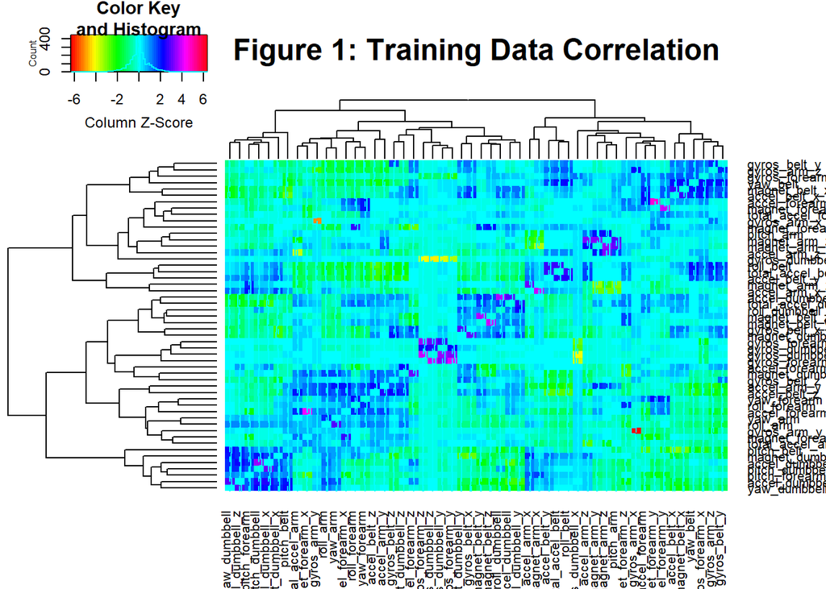

We notice only small pockets of significant correlation. Accordingly, we decided not to reduce the dimensions of data further, and instead work with all the remaining 52 columns of data.

## Partitioning the Training Dataset

Following the recommendations in Practical Machine Learning Course, we’d partition the supplied ‘in_train’ dataset between a training data set ‘training’ and a validation data set ‘myTesting’, in a 70-30 ratio. The latter should not be confused with the data in the pml-testing.csv file. We’d use cross validation within the training partition to improve the model fit and then do an out-of-sample test with the validation partition.

```r
# Partioning the supplied training data into two datasets, 70% for training and 30% for myTesting
library(caret)
set.seed(315)
index <- createDataPartition(y=in_train$classe, p=0.7, list=FALSE)
training <- in_train[index, ]
myTesting <- in_train[-index, ]
```

## Model Development

In our problem we have multiple numeric measurements of each observation to predict one of the five classifications. This is a classic problem to solve with tree classification or the Random Forest algorithm. However, we would consider additionally the stochastic gradient boosting method for the sake of comparison. The machine learning ‘caret’ package in R supports all three methods.

### 1) Classification Decision Tree

We’d first use classification trees to analyze the training dataset. We have to predict the ‘classe’ variable from rest of the variables in the dataset. We’d use ‘rpart’ method in the ‘train’ function of the ‘caret’ package for predicting the decision tree, and use the ‘rpart.plot’ package for plotting the decision tree.

We have already divided the downloaded in_train dataset into a ‘training’ set and another independent ‘myTesting’ dataset.

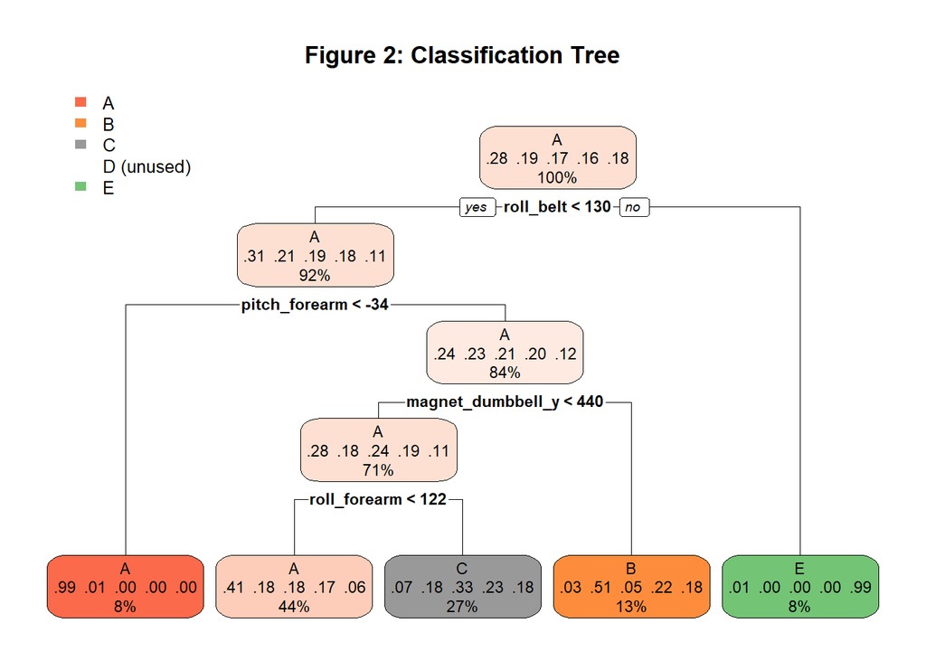

```r
set.seed(111)
modFitDT <- train(classe ~ ., method='rpart', data=training)

library(rpart.plot)
rpart.plot(modFitDT$finalModel, main = "Figure 2: Classification Tree")
```

The confusionMatrix function gives the count of how many times the predicted variable mapped correctly to the true values of the classe variable.

```r
set.seed(345)
predDT <- predict(modFitDT, myTesting)
confMatDT <- confusionMatrix(predDT, myTesting$classe)
print(confMatDT)
```

```
## Confusion Matrix and Statistics
##
##           Reference
## Prediction    A    B    C    D    E
##          A 1503  492  477  427  155
##          B   22  367   23  174  156
##          C  144  280  526  363  298
##          D    0    0    0    0    0
##          E    5    0    0    0  473
##
## Overall Statistics
##
##                Accuracy : 0.4875
##                  95% CI : (0.4747, 0.5004)
##     No Information Rate : 0.2845
##     P-Value [Acc > NIR] : < 2.2e-16
##
##                   Kappa : 0.3304
##  Mcnemar's Test P-Value : NA
##
## Statistics by Class:
##
##                      Class: A Class: B Class: C Class: D Class: E
## Sensitivity            0.8978  0.32221  0.51267   0.0000  0.43715
## Specificity            0.6317  0.92099  0.77670   1.0000  0.99896
## Pos Pred Value         0.4921  0.49461  0.32651      NaN  0.98954
## Neg Pred Value         0.9396  0.84989  0.88301   0.8362  0.88737
## Prevalence             0.2845  0.19354  0.17434   0.1638  0.18386
## Detection Rate         0.2554  0.06236  0.08938   0.0000  0.08037
## Detection Prevalence   0.5189  0.12608  0.27375   0.0000  0.08122
## Balanced Accuracy      0.7648  0.62160  0.64469   0.5000  0.71806
```

### 2) Boosting

Here we’d use the ‘gbm’ method (Boosting with Trees) of the ‘caret’ package for prediction. We use trainControl function to specify sampling parameters in the model. The object that is outputted from traincontrol is provided as an argument for train. Again, the Confusion Matrix is generated to validate accuracy of prediction against the independent dataset myTest.

```r
set.seed(222)
# Specify the resampling method
fitControl <- trainControl(method = "repeatedcv",
                           number = 5, # 5-fold CV
                           repeats = 1)

modFitBoost <- train(classe ~ ., method = "gbm", data = training,
                     trControl = fitControl, verbose = F)
```

Print the Boost model’s predictions on the training dataset, as well as on the myTest dataset:

```r
modFitBoost
```

```
## Stochastic Gradient Boosting
##
## 13737 samples
##    52 predictor
##     5 classes: 'A', 'B', 'C', 'D', 'E'
##
## No pre-processing
## Resampling: Cross-Validated (5 fold, repeated 1 times)
## Summary of sample sizes: 10990, 10990, 10990, 10988, 10990
## Resampling results across tuning parameters:
##
##   interaction.depth  n.trees  Accuracy   Kappa
##   1                   50      0.7484905  0.6811696
##   1                  100      0.8184480  0.7702773
##   1                  150      0.8528071  0.8137744
##   2                   50      0.8600871  0.8227789
##   2                  100      0.9090784  0.8849313
##   2                  150      0.9335381  0.9159082
##   3                   50      0.8993961  0.8726628
##   3                  100      0.9411082  0.9254750
##   3                  150      0.9593076  0.9485209
##
## Tuning parameter 'shrinkage' was held constant at a value of 0.1
##
## Tuning parameter 'n.minobsinnode' was held constant at a value of 10
## Accuracy was used to select the optimal model using the largest value.
## The final values used for the model were n.trees = 150,
##  interaction.depth = 3, shrinkage = 0.1 and n.minobsinnode = 10.
```

```r
set.seed(456)
predBoost <- predict(modFitBoost, newdata=myTesting)
confMatBoost <- confusionMatrix(predBoost, myTesting$classe)
confMatBoost
```

```
## Confusion Matrix and Statistics
##
##           Reference
## Prediction    A    B    C    D    E
##          A 1648   41    0    0    1
##          B   19 1068   22    4    8
##          C    4   26  991   32   12
##          D    1    2   10  922   12
##          E    2    2    3    6 1049
##
## Overall Statistics
##
##                Accuracy : 0.9648
##                  95% CI : (0.9598, 0.9694)
##     No Information Rate : 0.2845
##     P-Value [Acc > NIR] : < 2.2e-16
##
##                   Kappa : 0.9555
##  Mcnemar's Test P-Value : 5.834e-05
##
## Statistics by Class:
##
##                      Class: A Class: B Class: C Class: D Class: E
## Sensitivity            0.9845   0.9377   0.9659   0.9564   0.9695
## Specificity            0.9900   0.9888   0.9848   0.9949   0.9973
## Pos Pred Value         0.9751   0.9527   0.9305   0.9736   0.9878
## Neg Pred Value         0.9938   0.9851   0.9927   0.9915   0.9932
## Prevalence             0.2845   0.1935   0.1743   0.1638   0.1839
## Detection Rate         0.2800   0.1815   0.1684   0.1567   0.1782
## Detection Prevalence   0.2872   0.1905   0.1810   0.1609   0.1805
## Balanced Accuracy      0.9872   0.9632   0.9753   0.9757   0.9834
```

### 3) Random Forest

We’d run the Random Forest algorithm for prediction by using the ‘rf’ method in the ‘caret’ package. The standard randomForest() function of R requires tuning of two parameters, namely: **mtry**: Number of variables randomly sampled as candidates at each split, and **ntree**: Number of trees to grow. In ‘caret’ only mtry parameter is available for tuning. However, for the sake of simplicity we could leave it as default. One can get higher accuracy by increasing ntree - upto a limit - then it flattens. In first trial (commented out) we chose ntree = 100. In second and third iterations, we chose cross-validation similar to the Boosting model discussed before. However, (finally) unlike in Boosting model, we chose “out-of-bag” method with ten repeats, as it offers improved performance over K-fold for random forest models.

```r
set.seed(333)
# Alternative 3 (used): Set control for train function
# Uses out-of-bag cross validation, runs faster
tr <- trainControl(method = "oob", number = 10, allowParallel = TRUE)

# Alternative 2: trainControl method below specifies 10-Fold Cross Validation
# Object calculated one time and passed to the train function. train ran v. slow.
# ctrlRF <- trainControl(method = "repeatedcv", number = 5, repeats = 2)

# Alternative 1: No cross-validation
# modFitRF <- train(classe ~ ., method = 'rf', data = training, ntree = 100)
modFitRF  <- train(classe ~ ., data = training, method = "rf",
                   trControl = tr, verbose = FALSE)
modFitRF$finalModel
```

```
##
## Call:
##  randomForest(x = x, y = y, mtry = param$mtry, verbose = FALSE)
##                Type of random forest: classification
##                      Number of trees: 500
## No. of variables tried at each split: 27
##
##         OOB estimate of  error rate: 0.7%
## Confusion matrix:
##      A    B    C    D    E class.error
## A 3902    3    1    0    0 0.001024066
## B   19 2632    5    2    0 0.009781791
## C    0   13 2373   10    0 0.009599332
## D    0    2   26 2221    3 0.013765542
## E    0    1    3    8 2513 0.004752475
```

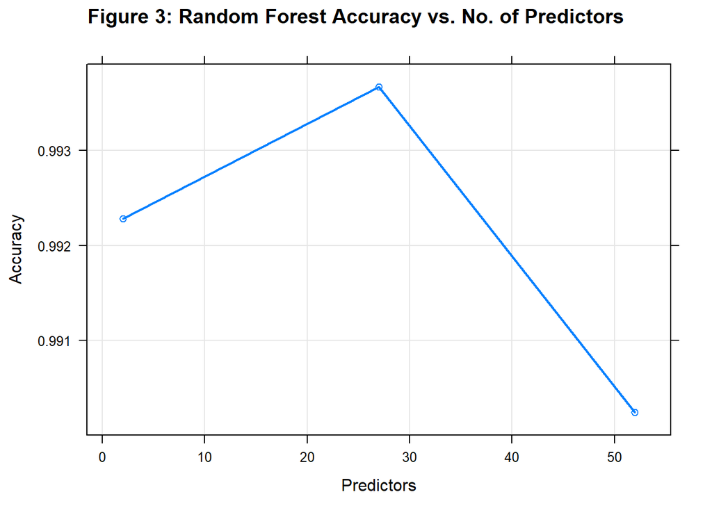

```r
plot(modFitRF, log = "y", lwd = 2, main = "Figure 3: Random Forest Accuracy vs. No. of Predictors", xlab = "Predictors", ylab = "Accuracy")
```

```r
set.seed(567)
predRF <- predict(modFitRF, newdata=myTesting, verbose=FALSE)
# predRF  # -> This statement would give large output
confMatRF <- confusionMatrix(predRF, myTesting$classe)
confMatRF
```

```
## Confusion Matrix and Statistics
##
##           Reference
## Prediction    A    B    C    D    E
##          A 1670    8    0    0    0
##          B    2 1129    1    1    0
##          C    1    2 1021   11    2
##          D    0    0    4  952    1
##          E    1    0    0    0 1079
##
## Overall Statistics
##
##                Accuracy : 0.9942
##                  95% CI : (0.9919, 0.996)
##     No Information Rate : 0.2845
##     P-Value [Acc > NIR] : < 2.2e-16
##
##                   Kappa : 0.9927
##  Mcnemar's Test P-Value : NA
##
## Statistics by Class:
##
##                      Class: A Class: B Class: C Class: D Class: E
## Sensitivity            0.9976   0.9912   0.9951   0.9876   0.9972
## Specificity            0.9981   0.9992   0.9967   0.9990   0.9998
## Pos Pred Value         0.9952   0.9965   0.9846   0.9948   0.9991
## Neg Pred Value         0.9990   0.9979   0.9990   0.9976   0.9994
## Prevalence             0.2845   0.1935   0.1743   0.1638   0.1839
## Detection Rate         0.2838   0.1918   0.1735   0.1618   0.1833
## Detection Prevalence   0.2851   0.1925   0.1762   0.1626   0.1835
## Balanced Accuracy      0.9979   0.9952   0.9959   0.9933   0.9985
```

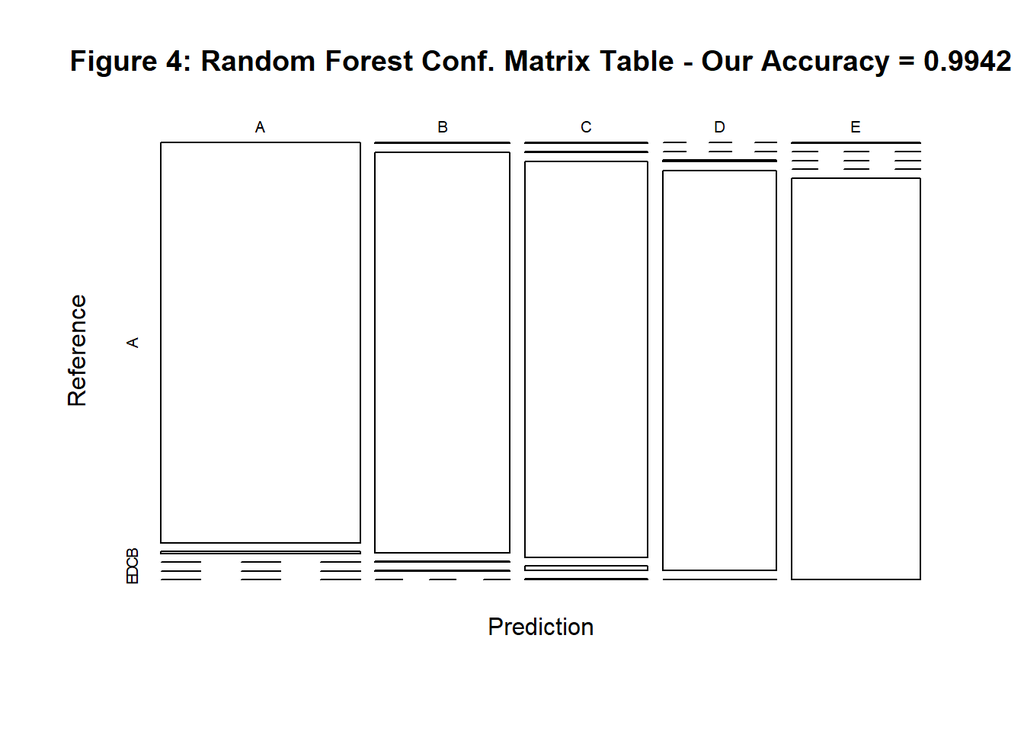

```r
plot(confMatRF$table, col = confMatRF$byClass,
     main = paste("Figure 4: Random Forest Conf. Matrix Table - Our Accuracy =",
                  round(confMatRF$overall['Accuracy'], 4)))
```

## Accuracies for the three models

```r
AccuracyResults <- data.frame(
  Model = c('Decision Tree', 'Boosting', 'Random Forest'),
   Accuracy = rbind(confMatDT$overall[1], confMatBoost$overall[1], confMatRF$overall[1]))

print(AccuracyResults)
```

```
##           Model  Accuracy
## 1 Decision Tree 0.4875106
## 2      Boosting 0.9648258
## 3 Random Forest 0.9942226
```

We notice that both Boosting and Random Forest models outperform the Decision Trees model, with Random Forest being slightly better in accuracy. We perform prediction on the testing dataset using the Random Forest model.

## Chosen Model and Out of Sample Error

```r
length(myTesting$classe) # no. in myTesting dataset - same as length(predRF)
```

```
## [1] 5885
```

```r
sum(predRF == myTesting$classe) # no. predicted correctly
```

```
## [1] 5851
```

```r
validationAccuracy <- sum(predRF == myTesting$classe)/length(predRF)
outOfSampleError <- 1 - validationAccuracy
# Out of sample error in percentage
e <- outOfSampleError * 100
paste0("Out of sample estimation error is: ", round(e, digits = 2), "%")
```

```
## [1] "Out of sample estimation error is: 0.58%"
```

## Predictions for the given test dataset

```r
predictionRF <- predict(modFitRF, newdata = testing)
predictionRF
```

```
##  [1] B A B A A E D B A A B C B A E E A B B B
## Levels: A B C D E
```

```r
testPredictionResults <- data.frame(
  problem_id = testing$problem_id,
  predicted = predictionRF
)
print(testPredictionResults)
```

```
##    problem_id predicted
## 1           1         B
## 2           2         A
## 3           3         B
## 4           4         A
## 5           5         A
## 6           6         E
## 7           7         D
## 8           8         B
## 9           9         A
## 10         10         A
## 11         11         B
## 12         12         C
## 13         13         B
## 14         14         A
## 15         15         E
## 16         16         E
## 17         17         A
## 18         18         B
## 19         19         B
## 20         20         B
```

```r
# File for submission
write.table(testPredictionResults, "./Prediction-Results.txt", sep=" ", row.names=FALSE)
```